# Aplicaciones con LLM y modelos Preentrenados

Técnicas de aprendizaje de máquina

Oscar Bustos

# Repaso

## Icebreaker: Trabajo Futuro

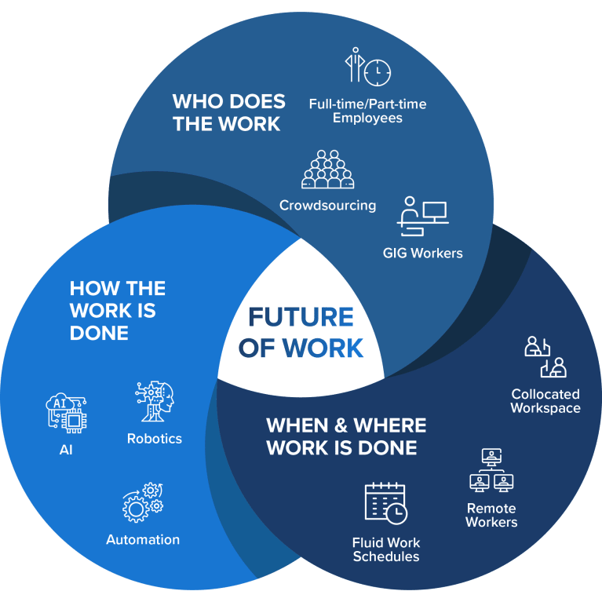

- ¿Cómo se realizará el trabajo en el futuro y quién lo llevará a cabo?

## Capítulos sobre Deep Learning

[figure not shown]

Capítulo 1 y 2

[figure not shown]

Capítulo 16

## Zoológico de Redes neuronales

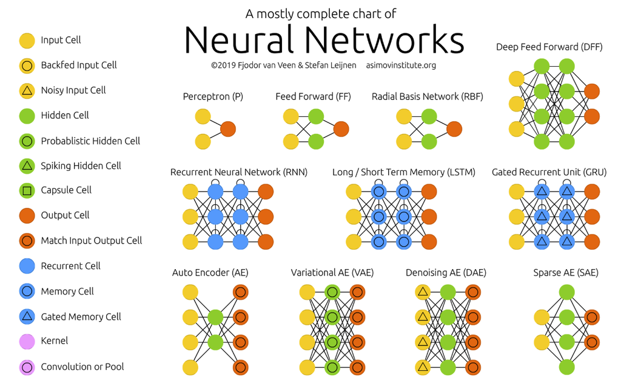

[The Neural Network Zoo](https://www.asimovinstitute.org/neural-network-zoo/)

## Zoológico de Redes neuronales

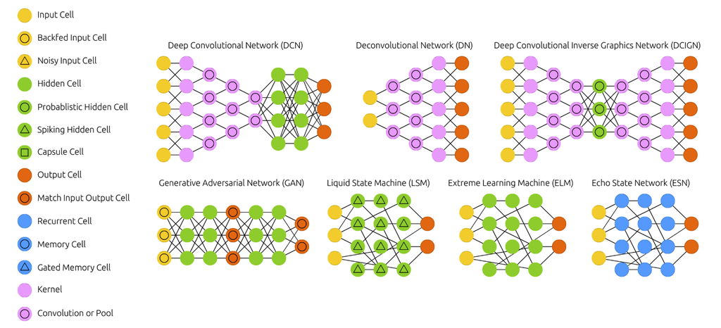

[The Neural Network Zoo](https://www.asimovinstitute.org/neural-network-zoo/)

## Zoológico de Redes neuronales

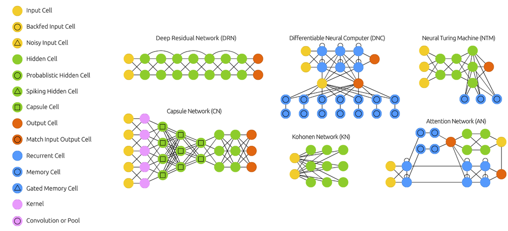

[The Neural Network Zoo](https://www.asimovinstitute.org/neural-network-zoo/)

## Attention Networks (AN)

**Aplicación Ideal:** Modelado de dependencias a largo plazo en datos secuenciales. - Traducción automática con Transformers. - Generación de resúmenes automáticos. - Análisis de documentos extensos. - Base de los Large Language Models (LLM)

# Búsqueda Semántica

## Tareas principales en PLN

Qué tipo de sistema utilizarías para resolver las siguientes preguntas: - ¿Cuáles 10 novelas son más parecidas a Cien Años de Soledad? - ¿Dame 5 imágenes similares a esta imagen de un colibrí? - ¿Cuál es el usuario que tiene las características de compra más parecidas a este adulto de 53 años? - ¿Cuáles de las llamadas de Call Center corresponden a clientes furiosos o no satisfechos con el servicio?

## Búsqueda en Sentencias Judiciales

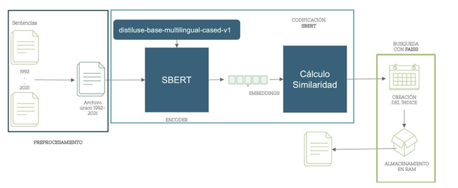

- Búsqueda semántica de sentencias judiciales usando técnicas actuales del NLP y métodos de recuperación de información ((Martínez Pinilla 2022))

## Recomendación en Libros

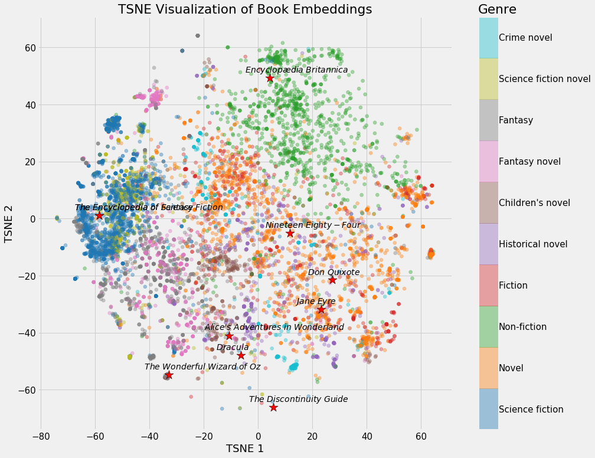

Representación vectorial de una colección de Libros ([enlace](https://towardsdatascience.com/neural-network-embeddings-explained-4d028e6f0526/))

## Procesamiento de Lenguaje Natural

El Procesamiento de Lenguaje Natural (PLN) es una subdisciplina de la inteligencia artificial que se enfoca en la interacción entre las computadoras y los lenguajes humanos.

Implica el desarrollo de algoritmos y modelos para comprender, interpretar y generar lenguaje humano.

## Índice Invertido

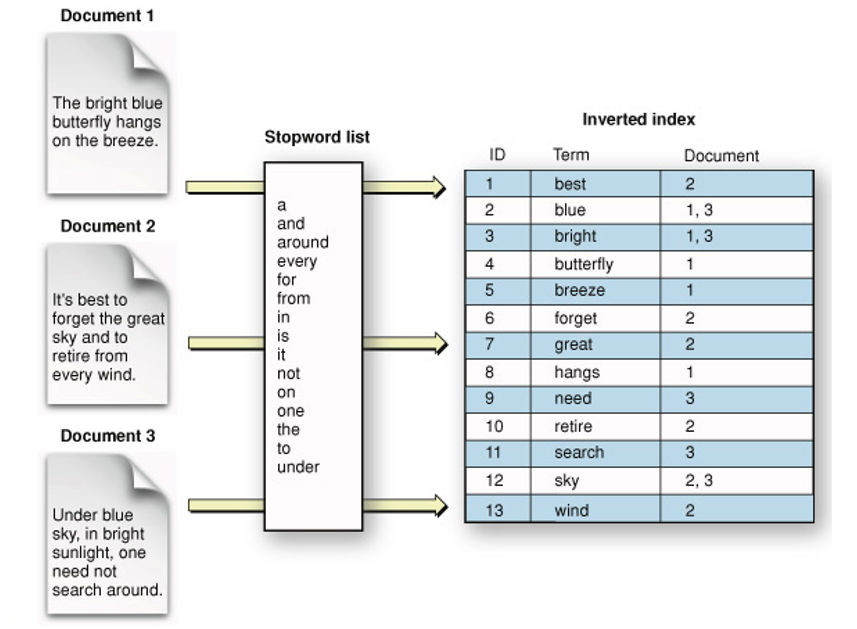

Indice Invertido

## Tokenización

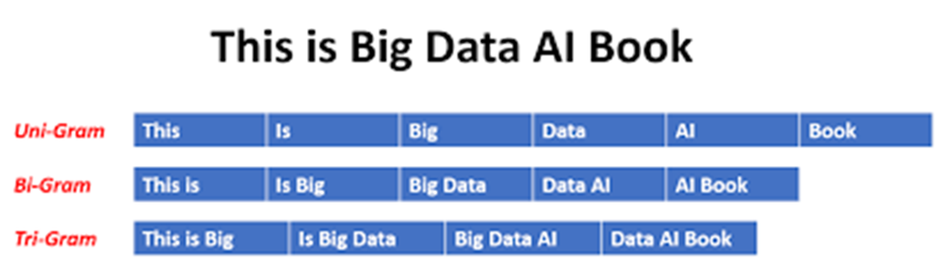

Tokenización

## Nube de Palabras

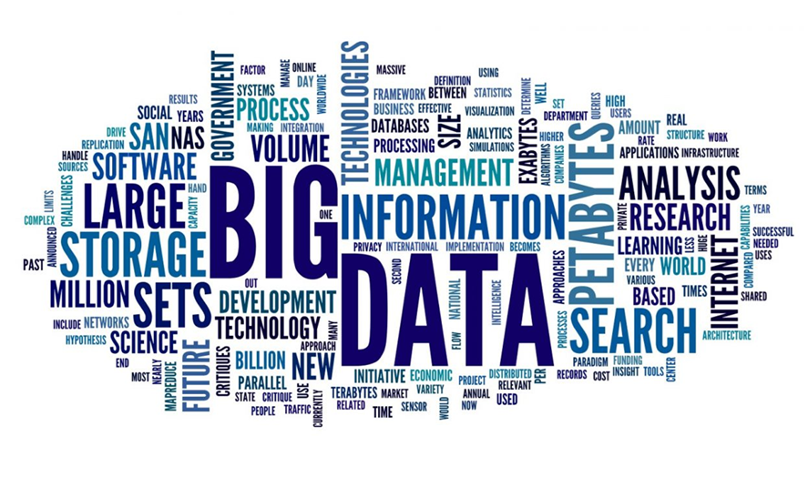

Nube de Palabras

## Cómo leer un libro en PDF en Segundos

1. **Extraer el texto del PDF:**
- Utiliza herramientas como `pdftotext` (en Linux/macOS) o aplicaciones en línea.
- Guarda el texto extraído en un archivo `.txt`.
1. **Limpiar el texto:**
- Elimina caracteres especiales, números y palabras comunes (stop words).
- Puedes usar scripts en Python con librerías como `nltk`.
1. **Generar la nube de palabras:**
- Puedes usar librerías de Python como `wordcloud`.

## Lexicon

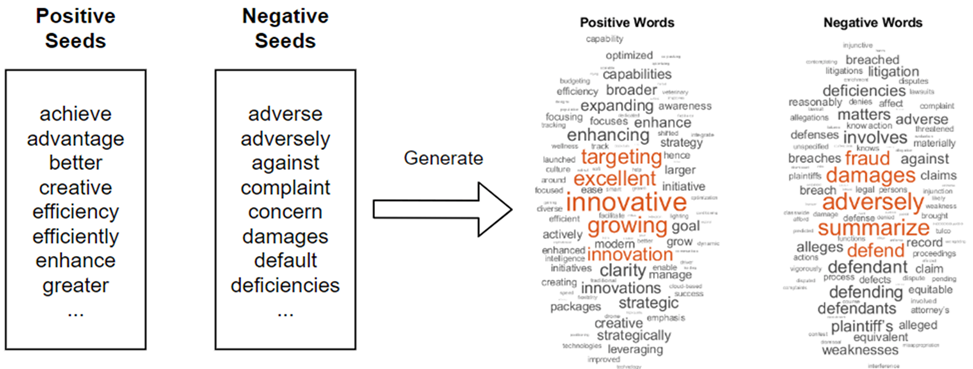

Lexicon

## Análisis de Sentimientos

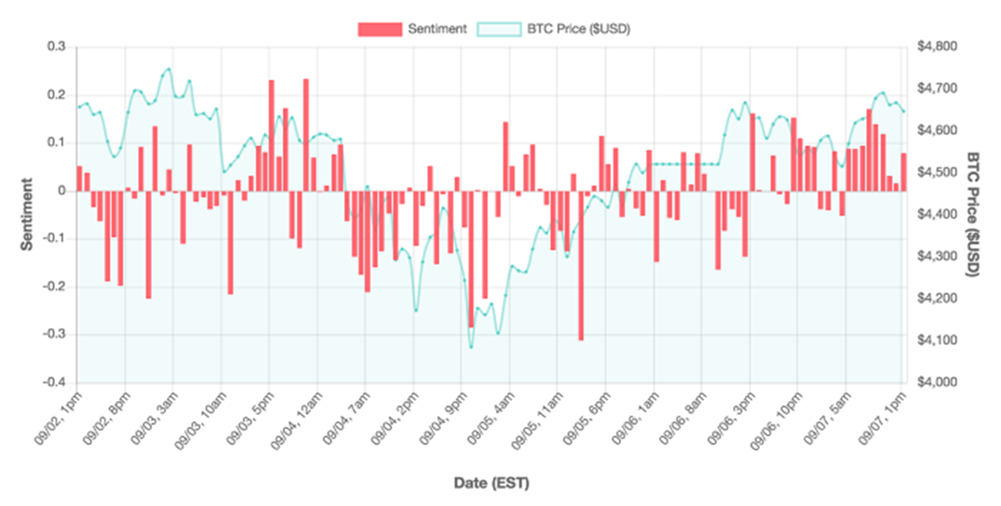

Análisis de Sentimientos

## Algoritmo Word2Vec

**Objetivo:** Aprender representaciones vectoriales densas (embeddings) de palabras, donde las palabras con significados o contextos similares tienen vectores numéricos cercanos.

- Utiliza una red neuronal superficial (de una sola capa oculta).
- **Arquitecturas principales:**
  - **CBOW (Continuous Bag-of-Words):** Predice una palabra objetivo a partir de las palabras de su contexto.
  - **Skip-Gram:** Predice las palabras del contexto circundante a partir de una palabra objetivo dada.
- **Propiedad clave:** Captura relaciones semánticas y sintácticas mediante operaciones algebraicas (ej. $V(\text{Rey}) - V(\text{Hombre}) + V(\text{Mujer}) \approx V(\text{Reina})$).

(Mikolov et al. 2013)

## Embedding

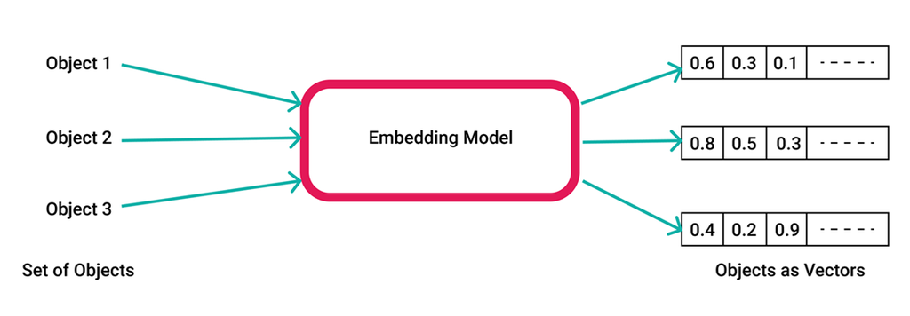

Ingeniería de características con Embeddings

## Embeddings

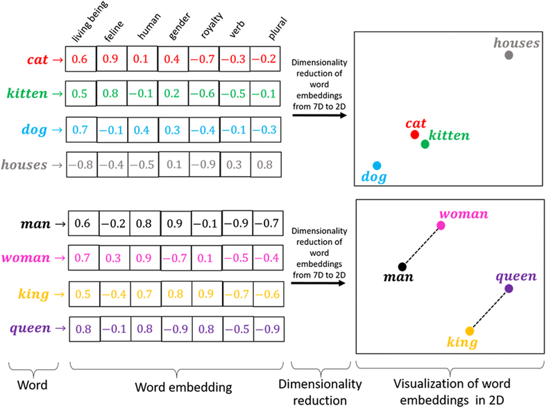

## Embeddings

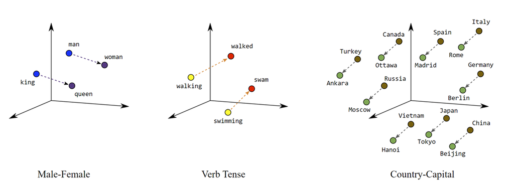

## Embeddings

[figure not shown]

## Modelos de transformadores

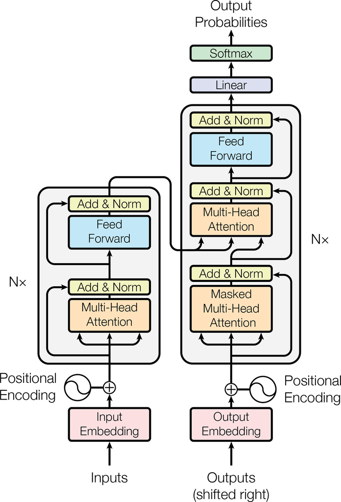

Modelos de Transformadores https://poloclub.github.io/transformer-explainer/

# Interfaces Conversacionales con LLM

## APIs de Modelos de Lenguaje Extensos (LLMs)

- Se pueden desarrollar aplicaciones integrando APIs de modelos de lenguaje de gran tamaño (LLMs).
- Los nuevos modelos procesan multimedia (imágenes, documentos, voz y video).
- Principales proveedores y modelos recientes (2026):
  - **OpenAI**: GPT-5.5 Pro y GPT-5.5 ([OpenAI Pricing](https://openai.com/api/pricing/))
  - **Google Gemini**: Gemini 3.1 Pro y Gemini 3 Flash ([Gemini Models](https://ai.google.dev/gemini-api/docs/models))
  - **DeepSeek**: DeepSeek-V4-Pro y DeepSeek-V4-Flash ([DeepSeek Models](https://api-docs.deepseek.com/updates))
- Cada modelo tiene capacidades y costos distintos según la aplicación deseada.

## Interacción con la API de Google AI Studio y la interfaz Gradio

Para más detalles sobre los modelos disponibles, visite: https://aistudio.google.com/

## Introducción a Retrieval-augmented generation

- Los modelos de lenguaje grandes (LLMs) tienen limitaciones:
  - Conocimiento limitado a los datos de entrenamiento.
  - Pueden generar información falsa (alucinaciones).
  - Falta de conocimiento específico de dominio.
- Retrieval-augmented generation (RAG) mejora los LLMs al consultar bases de conocimiento externas.
- Combina técnicas de recuperación de información con capacidades generativas de LLMs.
- Beneficios:
  - Mayor precisión y reducción de alucinaciones.
  - Acceso a información actualizada y específica.
  - Rentable y escalable.

## Arquitectura Conceptual

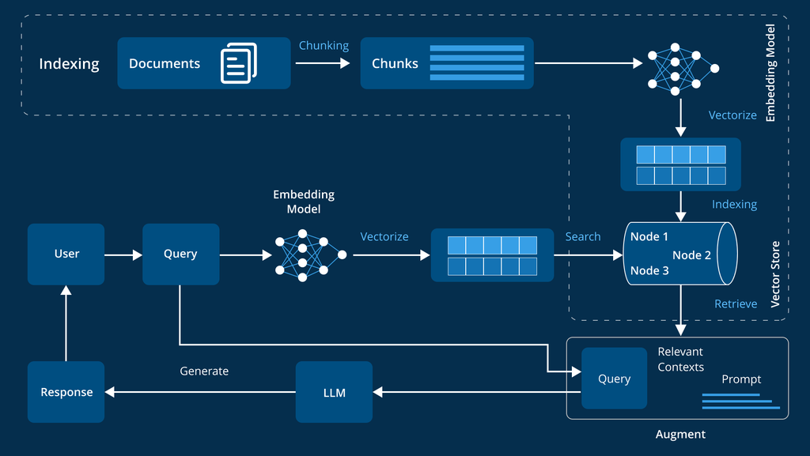

[Arquitectura de Referencia](https://www.leewayhertz.com/advanced-rag/)

## Arquitectura de Referencia - AWS

[figure not shown]

[Chatbots With Vector Databases AWS](https://aws.amazon.com/solutions/guidance/chatbots-with-vector-databases-on-aws/)

## Arquitectura de Referencia - MELI

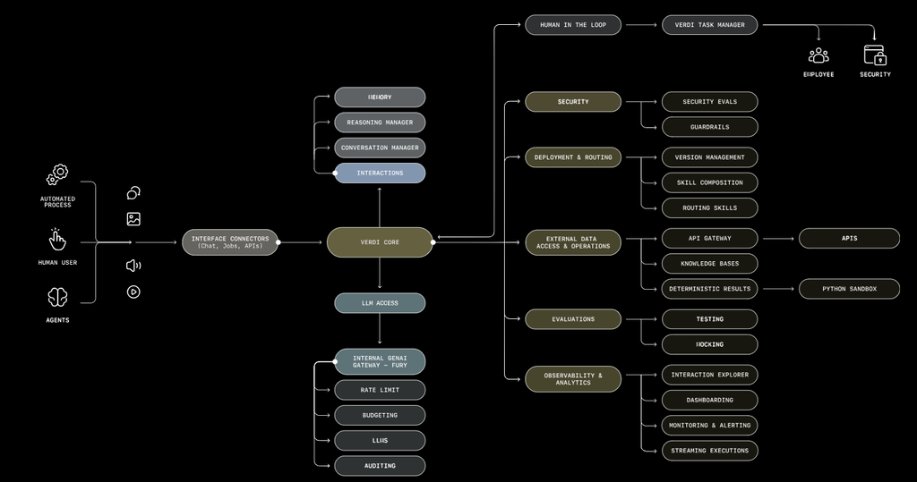

[Plataforma de desarrollo con LLMs en Mercadolibre](https://openai.com/index/mercado-libre/)

## Componentes Clave de RAG

- **LLMs Pre-entrenados**: Núcleo generativo (GPT, Llama, Gemini).
- **Modelos de Embedding**: Representaciones vectoriales del texto (text-embedding-ada-002, jina-embeddings-v2).
- **Bases de Datos Vectoriales**: Almacenan y buscan embeddings (Pinecone, Weaviate, Chroma DB).
- **Mecanismos de Recuperación**: Algoritmos para obtener información relevante (búsqueda semántica, por palabras clave).
- **Bases de Conocimiento**: Fuentes de datos externas (documentos, bases de datos, APIs).
- **Consultas de Entrada**: Preguntas del usuario.

## References

Martínez Pinilla, Manuel Francisco. 2022. *Búsqueda Semántica de Sentencias Judiciales Usando Técnicas Actuales Del NLP y Métodos de Recuperación de Información*. http://hdl.handle.net/10554/62083.

Mikolov, Tomas, Kai Chen, Greg Corrado, and Jeffrey Dean. 2013. “Efficient Estimation of Word Representations in Vector Space.” *arXiv Preprint arXiv:1301.3781*.